# UNIT07B 案例：航空公司的市場區隔

中山大學管理學院 卓雍然

2021-04-13 01:53:25

市場區隔-對不同顧客做不同市場分析;對員工做分群分析可針對不同員工做不同的教育訓練。 針對特徵的不同做分群並且延伸做管理

```r
pacman::p_load(dplyr, d3heatmap)
if (!require("devtools")) install.packages("devtools")
devtools::install_github("rstudio/d3heatmap")
```

### 【A】航空公司顧客資料集

```r
A = read.csv('data/AirlinesCluster.csv')
summary(A)
```

```
    Balance          QualMiles       BonusMiles       BonusTrans
 Min.   :      0   Min.   :    0   Min.   :     0   Min.   : 0.0
 1st Qu.:  18528   1st Qu.:    0   1st Qu.:  1250   1st Qu.: 3.0
 Median :  43097   Median :    0   Median :  7171   Median :12.0
 Mean   :  73601   Mean   :  144   Mean   : 17145   Mean   :11.6
 3rd Qu.:  92404   3rd Qu.:    0   3rd Qu.: 23800   3rd Qu.:17.0
 Max.   :1704838   Max.   :11148   Max.   :263685   Max.   :86.0
  FlightMiles     FlightTrans    DaysSinceEnroll
 Min.   :    0   Min.   : 0.00   Min.   :   2
 1st Qu.:    0   1st Qu.: 0.00   1st Qu.:2330
 Median :    0   Median : 0.00   Median :4096
 Mean   :  460   Mean   : 1.37   Mean   :4119
 3rd Qu.:  311   3rd Qu.: 1.00   3rd Qu.:5790
 Max.   :30817   Max.   :53.00   Max.   :8296
```

**欄位定義：**  
■ `Balance`: 可用里程數  
■ `QualMiles`: 可用高級里程數  
■ `BonusMiles`: 過去12個月非飛行里程數  
■ `BonusTrans`: 過去12個月非飛行交易次數  
■ `FlightMiles`: 過去12個月飛行里程數  
■ `FlightTrans`: 過去12個月飛行交易次數  
■ `DaysSinceEnroll`: 會員年資 (天)

### 【B】資料標準化

💡 `scale(df)` 標準化：讓資料框之中每一個欄位的平均值都等於`0`、標準差都等於`1`

🗿 **`Q:`** 集群分析和尺度縮減之前，為甚麼常要先做資料標準化呢？  
在分群的時候讓每個數值的權重一致 對每一個分群的欄位做標準化＝對一向量做標準化（平均值＝0,標準差＝1） 對這向量減掉他的平均值/標準差 也可以說是 將每個數值的起點拉成一致,這樣能更容易看出每個數值的差異，進而做比較。

```r
AN = scale(A) %>% data.frame
```

```r
sapply(AN, mean) #標準化過後平均值幾乎等於零
```

```
                 Balance                QualMiles               BonusMiles
 0.000000000000000027654  0.000000000000000026507 -0.000000000000000042736
              BonusTrans              FlightMiles              FlightTrans
-0.000000000000000071911  0.000000000000000014818  0.000000000000000010741
         DaysSinceEnroll
 0.000000000000000055637
```

```r
sapply(AN, sd) #標準化後標準差都=1
```

```
        Balance       QualMiles      BonusMiles      BonusTrans     FlightMiles
              1               1               1               1               1
    FlightTrans DaysSinceEnroll
              1               1
```

### 【C】層級式集群分析 Hirarchical Clustering

1.距離矩陣

```r
d = dist(AN, method="euclidean")
```

2.層級式集群分析

```r
hc = hclust(d, method='ward.D')
```

3.畫出樹狀圖 Dendrogram

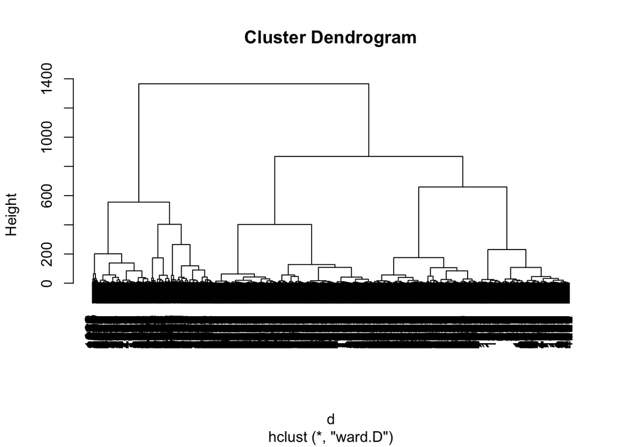

```r
plot(hc) #樹狀圖的垂直高度代表 每一個集群到達中心點的平均距離 分兩群後讓每一群的平均距離較短一點
```

```r
#最好是讓下降幅度高一點
```

💡 樹狀圖中的垂直線段高度，代表分群之後，群內各點到族群中心點的平均距離縮短的幅度。

🗿 **`Q:`** 如何從樹狀圖決定群數？  
依所選目標做分群，盡量目標群間差異大一點。

一個集群到達中心點的平均距離 分兩群後讓每一群的平均距離短一點，但最好是讓下降幅度高一點。 因為可以了解每群差異點在哪，但如果差異不大再分群是沒有意義因為太相似，且無法對兩群作命名。

4.分割群組、製作分群向量

```r
kg = cutree(hc, k=5)
```

### 【D】觀察群組特性

做完分群向量之後，通常要先觀察每一個族群的大小

```r
table(kg)
```

```
kg
   1    2    3    4    5
 776  519  494  868 1342
```

然後我們觀察每一個族群、每一個變數的平均值

```r
names(A) = names(AN) =c(
  "里程數","高級里程數","非飛行里程","非飛行交易",
  "飛行里程","飛行交易","會員年資")

sapply(split(A,kg), colMeans) %>% round(2)  # 原始尺度 對五群的每一個哩程數做平均數 第一群平均哩程數
```

```
                  1         2         3        4        5
里程數     57866.90 110669.27 198191.57 52335.91 36255.91
高級里程數     0.64   1065.98     30.35     4.85     2.51
非飛行里程 10360.12  22881.76  55795.86 20788.77  2264.79
非飛行交易    10.82     18.23     19.66    17.09     2.97
飛行里程      83.18   2613.42    327.68   111.57   119.32
飛行交易       0.30      7.40      1.07     0.34     0.44
會員年資    6235.36   4402.41   5615.71  2840.82  3060.08
```

```r
#split(A,kg)用kg切開Ａ
```

若要畫成圖較困難，因為每個值的範圍太大 大得很大小的很小，容易看不清楚 沈睡顧客–是顧客但已經很久沒有消費了

```r
sapply(split(AN,kg), colMeans) %>% round(2)  # 標準化尺度比較的基礎是0，將每個族群的起點拉成一致
```

```
               1    2     3     4     5
里程數     -0.16 0.37  1.24 -0.21 -0.37
高級里程數 -0.19 1.19 -0.15 -0.18 -0.18
非飛行里程 -0.28 0.24  1.60  0.15 -0.62
非飛行交易 -0.08 0.69  0.84  0.57 -0.90
飛行里程   -0.27 1.54 -0.09 -0.25 -0.24
飛行交易   -0.28 1.59 -0.08 -0.27 -0.25
會員年資    1.03 0.14  0.72 -0.62 -0.51
```

**直條圖**

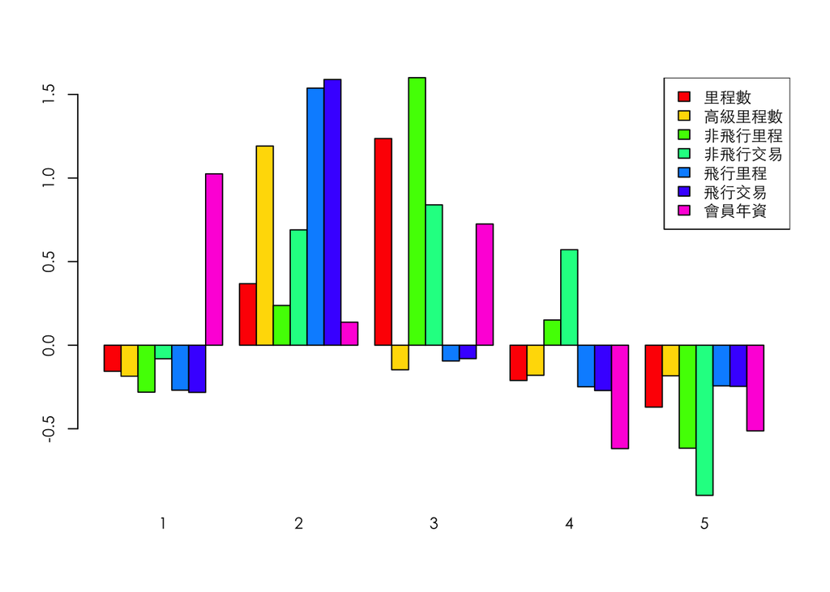

```r
par(family=('Heiti TC Light'))
par(cex=0.8)
split(AN,kg) %>% sapply(colMeans) %>% barplot(beside=T,col=rainbow(7))
legend('topright',legend=colnames(A),fill=rainbow(7))
```

往上是高於平均 往下是低於平均 **熱圖**

```r
par(family=('Heiti TC Light'))
cols = colorRamp(c('seagreen','lightyellow','red'))
sapply(split(AN,kg), colMeans) %>% d3heatmap(col=cols)
```

[interactive chart not shown]

🗿 討論問題：  
■ 分群平均值的代表什麼？ 它們的的商業意義是什麼？  
分群平均值：可以了解每一群的變數是在整體平均值高於還是低於。  
商業意義：可以了解每個群體的差異，針對不同群體做不同的決策。 ■ 「原始尺度」和「標準化尺度」各有什麼優缺點？  
原始尺度：優點：可了解每一群數值，觀察每一個族群、每一個變數的平均值 ;缺點：不能比較  
標準化尺度：優點：可比較各群的差異並了解其特徵值，方便暸解該族群在每一個變數的差異；缺點：無法了解實際數值。  
■ 什麼時候要用原始尺度？ 什麼時候要用標準化尺度？  
在需要觀察單一群的值時可以使用原始尺度。  
在需要各群相互比較或想了解群間差異時可使用標準化尺度。

🗿 討論問題：  
■ 統計上最好的分群也是實務上最好的分群嗎？  
不是 ■ 除了考慮群間和群間距離之外，實務上的分群通常還需要考慮那些因素？什麼樣變數可以做分群？  
還需要考慮那些因素：好辨識好溝通好操作 在做分群時，要對此族群做命名，發現與其他群的某群差不多則此為不好的分群。 什麼樣變數可以做分群：了解為什麼要做分群，有了目的目標才能知道應該抓什麼變數。抓取到最相關變數對達到目標才有幫助， 這也是為什麼要先挑變數才能做分群的原因。例如：商品促銷時，分群了一百多個，但最後也是挑出特徵值較突出的前十個。